# matplotlib_intro

## matplotlib

There are several Python visualization tools being matplotlib the most developed 2d/3d general purpose plotting package. The syntax is very similar to matlab.

#### plot

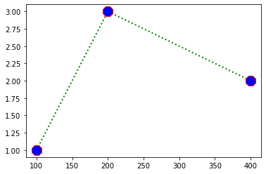

```python
%matplotlib inline
#import matplotlib
#matplotlib.use('nbagg')

import pylab as pl
#pl.ion()
pl.plot([100,200,400],[1,3,2],'g:8',lw=2,ms=15,mec='r',mfc='b');
#pl.show()
#help(pl.plot)
```

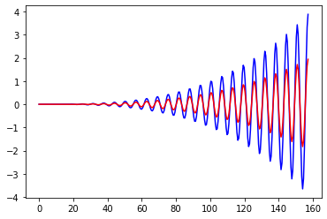

```python
import numpy as np
x=np.linspace(0,50*np.pi,300)
y=1e-6*np.cos(x)*x**3
y1=0.5e-6*np.cos(x)*x**3

pl.plot(x,y,'b',x,y1,'r');
#pl.savefig('teste.png')
```

#### saving the figure

pl.savefig(nome.ext)

Supports png, pdf, eps, svg, etc, or a buffer

#### histogram

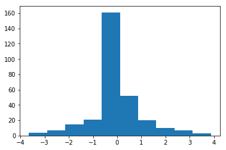

```python
pl.hist(y);
```

#### fill between

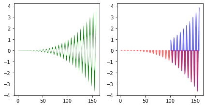

```python
fig,ax=pl.subplots(1,2)
fig.set_size_inches((7,3.5))
ax[0].fill_between(x,y,y1,color='g',alpha=1,lw=0.1)
ax[1].fill_between(x,y,0,color='b',alpha=.5,where=x>100)
ax[1].fill_between(x,y,0,color='r',alpha=.5,where=y<0);
```

#### pcolormesh, contourf, contour

```python
f='data/sst/sst_iberia.npz'
a=np.load(f,allow_pickle=1,encoding='bytes')
print(list(a))

for n in a:
    print(n,a[n].shape)
```

```
['h', 'sst_mask', 'sst', 'time', 'y', 'x']
h (295, 346)
sst_mask (295, 346)
sst (295, 346)
time ()
y (295, 346)
x (295, 346)
```

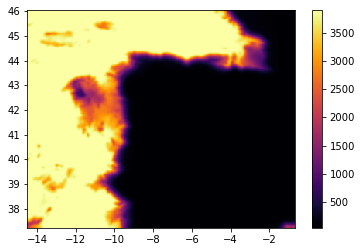

```python
v=a['sst']
v=np.ma.masked_where(a['sst_mask']==1,a['sst'])
lon=a['x']
lat=a['y']
pl.pcolormesh(lon,lat,a['h'],cmap=pl.cm.inferno,shading='auto')
pl.colorbar()
#v
```

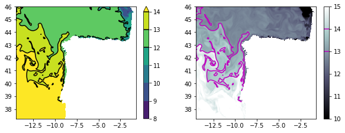

```python
x=a['x']
y=a['y']
sst=a['sst']
cond=sst>1e30
sst=np.ma.masked_where(cond,sst) # masked regions are not considered

fig,ax=pl.subplots(1,2)
fig.set_size_inches((10,3.5))

h=ax[0].contourf(x,y,sst,np.arange(8,15,1),extend='max')
l=ax[0].contour(x,y,sst,np.arange(12,15,1),colors='k')
cb=pl.colorbar(h,ax=ax[0]);
cb.add_lines(l)

h=ax[1].pcolormesh(x,y,sst,vmin=10,vmax=15,cmap=pl.cm.bone)
l=ax[1].contour(x,y,sst,[13,14],colors='m');
cb=pl.colorbar(h,ax=ax[1]);
cb.add_lines(l)
```

#### quiver

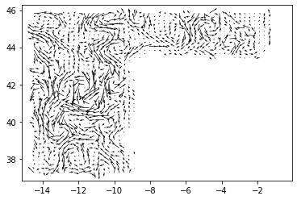

```python
a=np.load('data/uv/uv_iberia.npz')
mask=a['mask']
u=np.ma.masked_where(mask,a['u'])
v=np.ma.masked_where(mask,a['v'])
pl.quiver(a['lon'],a['lat'],u,v,units='width',width=0.002,scale=5);
```

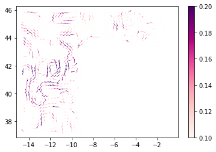

```python
speed=(u**2+v**2)**.5
h=pl.quiver(a['lon'],a['lat'],u,v,speed,units='width',width=0.002,scale=8,
          cmap='RdPu',clim=(.1,.2));
pl.colorbar(h);
```

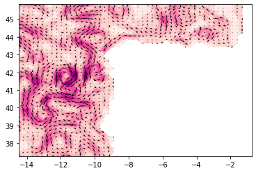

```python
pl.contourf(a['lon'],a['lat'],speed,cmap='RdPu')
h=pl.quiver(a['lon'],a['lat'],u,v,units='width',width=0.002,scale=8,
          color='k',clim=(.1,.2));
```

##### annotations and text boxes

It is very easy to add and manipulate text and labels, including latex code.

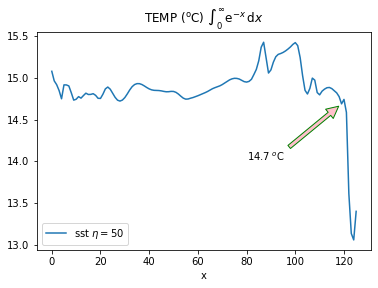

```python
pl.plot(sst[50,:],label='sst $\eta=50$')
pl.annotate('%.1f $^o$C'%sst[50,119], xy=(119, sst[50,119]), xytext=(80,14),
            arrowprops=dict(facecolor='pink',ec='green', shrink=0.05),
            )
pl.legend(loc='lower left')
pl.title('TEMP ($^\mathrm{o}$C) $\int_0^\infty \mathrm{e}^{-x}\,\mathrm{d}x$')
ax=pl.gca()
ax.set_xlabel('x'); # or pl.xlabel('x')
```

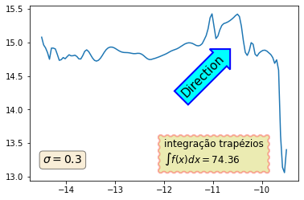

```python
ax=pl.gca()
xj=x[50]
yj=sst[50]
ax.plot(xj,yj)


textstr=r'$\sigma=%.1f$'%sst[50,:].std()
props = dict(boxstyle='round', facecolor='wheat', alpha=0.5)
ax.text(0.05, 0.15, textstr, transform=ax.transAxes, fontsize=14,
        verticalalignment='top', bbox=props)

bbox_props = dict(boxstyle="rarrow,pad=0.3", fc="cyan", ec="b", lw=2)
ax.text(-11.2, 14.5, "Direction", ha="center", va="center", rotation=45,
            size=15,bbox=bbox_props)

from scipy.integrate import trapz
textstr=u'integração trapézios\n'+r'$\int f(x)dx=%.2f$'%trapz(yj,xj)

bbox_props = dict(pad=0.7,boxstyle="roundtooth", fc="y", ec="r", lw=2,alpha=0.3)
ax.text(0.5, 0.1, textstr,
            size=12,bbox=bbox_props,transform=ax.transAxes);
```

#### time series

Matplotlib can deal with dates as arrays of datetime objects, e.g.:

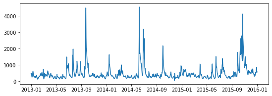

```python
a=np.load('data/ts/itajai.npz',allow_pickle=True)
t=a['time']
q=a['q']
pl.plot(t,q)
pl.gcf().set_size_inches((9,3))
```

let's make this look better...

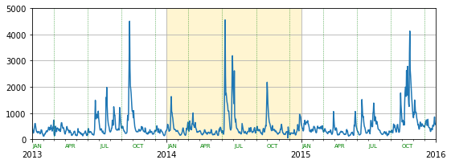

```python
import datetime
date0=datetime.datetime(2013,1,1)
date1=datetime.datetime(2016,1,1)

fig,ax=pl.subplots(1)
fig.set_size_inches((9,3))
ax.plot(t,q)

ax.set_xlim(date0,date1)
ax.set_ylim(0,5000)
ax.xaxis.grid(1)
ax.yaxis.grid(1)

# x ticks and labels:
years=pl.matplotlib.dates.YearLocator()
months=pl.matplotlib.dates.MonthLocator()
yfmt=pl.matplotlib.dates.DateFormatter('%Y')

ax.xaxis.set_major_locator(years)
ax.xaxis.set_tick_params(pad=10)
ax.xaxis.set_major_formatter(yfmt)
ax.xaxis.set_minor_locator(months)

d0=datetime.datetime(2014,1,1)
d1=datetime.datetime(2015,1,1)
yl=ax.get_ylim()
ax.fill([d0,d1,d1,d0],[yl[0],yl[0],yl[1],yl[1]],'#fff5d1',zorder=0.9)

import matplotlib.transforms as transforms
# the x coords of this transformation are data, and the
# y coord are axes (0 to 1)
trans = transforms.blended_transform_factory(
    ax.transData, ax.transAxes)

for y in range(2013,2016):
    for m in [3,6,9,12]:
        d=datetime.datetime(y,m-2,16)
        ax.text(d,-0.03,d.strftime('%b').upper(),transform=trans,
                fontsize=7,va='top',ha='center',color='g')
        d=datetime.datetime(y,m,1)
        ax.plot([d,d],ax.get_ylim(),'g--',lw=0.5,alpha=0.7)
```

#### transforms

In the previous time series example we used a transform to place text using data at x and axes coords at y. Let's play a little with this:

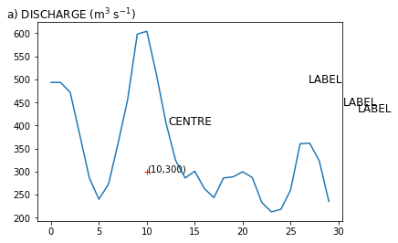

```python
ax=pl.axes()
pl.plot(q[:30])

# put some label at the center of the axes:
pl.text(.5,.5,'CENTRE',ha='center',va='center',transform=ax.transAxes,fontsize=12)
# or at upper left corner:
pl.text(-0.1,1,'a) DISCHARGE (m$^3$ s$^{-1}$)',ha='left',va='bottom',
        transform=ax.transAxes,fontsize=12)

# label at data x,y:
xo=10
yo=300
pl.plot(xo,yo,'r+')
pl.text(xo,yo,'(%d,%d)'%(xo,yo))

# label ax mixed coordinates (end of x axis, y=500):
trans = transforms.blended_transform_factory(
    ax.transAxes, ax.transData)
pl.text(1,500,'LABEL',ha='right',va='center',transform=trans,fontsize=12);
pl.text(1,450,'LABEL',ha='left',va='center',transform=trans,fontsize=12);
pl.text(1.05,450,'LABEL',ha='left',va='top',transform=trans,fontsize=12);
```

### Exercício

Grafica a expressao do crescimento populacional do Brasil (usa tempo em anos de 1800 a 2030). Cria o script exercicios/populacao_br.py

[figure not shown]

(t=tempo em anos)

Ilustra e coloca no título o valor deste ano

ex. do matlab:

[figure not shown]

```python
tempo=np.arange(1800,2031)
```

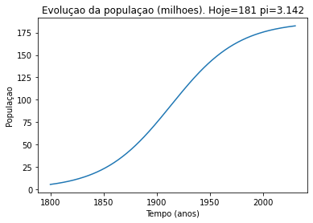

```python
tempo=np.arange(1800,2031)
P=187.273/(1+np.e**(-0.0313*(tempo-1913.25)))
pl.plot(tempo,P)
u=P[tempo==2023]
pl.title('Evoluçao da populaçao (milhoes). Hoje=%d pi=%.3f'%(u,np.pi))
pl.xlabel('Tempo (anos)')
pl.ylabel('Populaçao')
```

### Exercício:

```
usar os dados do Itajaí para criar um box plot
(exercicios/box_plot.py)
1- usar boxplot do matplotlib (pl.boxplot)
2- criar uma funçao para gerar boxplots horizontais!
```

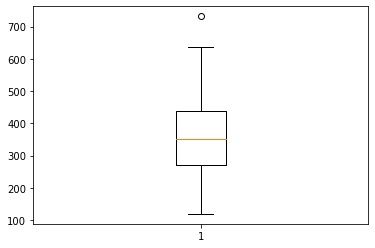

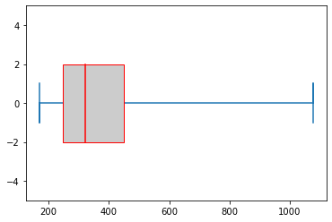

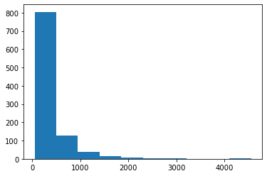

```python
def ler():
    a=np.load('data/ts/itajai.npz',allow_pickle=True)
    t=a['time']
    q=a['q']
    return t,q

def ver():
    x,y=ler()
    pl.plot(x,y)
    pl.gcf().set_size_inches((9,3))

def ver_box():
    x,y=ler()
    pl.boxplot(y[:100])

ver_box()

def boxploth(x):
    p=np.percentile(x,[5,25,50,75,95])
    fig=pl.figure()
    ax=pl.axes()
    ax.plot([p[0],p[0],p[0],p[-1],p[-1],p[-1]],[1,-1,0,0,1,-1])

    ax.fill([p[1],p[1],p[3],p[3],p[1]],[2,-2,-2,2,2],'#cccccc',ec='r',zorder=3)
    ax.plot([p[2],p[2]],[-2,2],'r',zorder=4)
    ax.set_ylim(-5,5)

x,y=ler()
boxploth(y[:1000])
pl.figure()
pl.hist(y[:1000])
```

### scatter

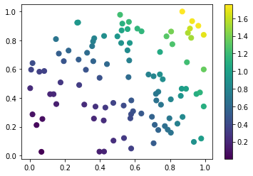

```python
x=np.random.random(100)
y=np.random.random(100)
if 1:
    pl.scatter(x,y,50,x**2+y**2)
    pl.colorbar()
else:
    pl.plot(x,y,'bo')
```

### subplots

```
(-1.6837204717028262,
 2.1754152605572776,
 -1.9079347346234787,
 1.4108363670388047)
```

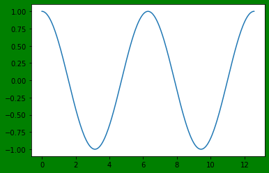

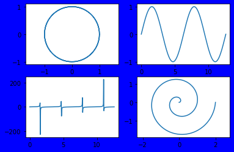

```python
x=np.linspace(0,2*2*np.pi,360)
fig=pl.figure()
fig.patch.set_facecolor('g')
ax=pl.axes()
ax.plot(x,np.cos(x))

fig,ax=pl.subplots(2,2)
fig.patch.set_facecolor('b')


#ax.plot(x,np.cos(x))
ax[0,0].plot(np.cos(x),np.sin(x))
ax[0,0].axis('equal')

ax[0,1].plot(x,np.sin(x))
ax[1,0].plot(x,np.tan(x))
r=np.linspace(0,2,x.size)
ax[1,1].plot(r*np.cos(x),r*np.sin(x))

ax[1,1].set_xlim(-3,3)
ax[1,1].axis('equal')
```

### Exercício:

- Cria o script exercicios/teste_scatter.py
- Cria dois vectores u, v aleatórios de distribuiçao normal (np.random.normal) com 1000 elementos.
- Cria uma figura com 3 subplots
- Plota um histograma dos dois vectores e faz um scatter plot de u e v.
- Adicionar mapeamento de cores associado a um terceiro vector (ex.: u^2+v^2)
- Adiciona colorbar
- Verifica limite de cores (opçao vmin e vmax do scatter)
- alterar color map (opçao cmap)

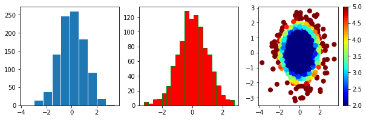

```python
u=np.random.normal(size=1000)
v=np.random.normal(size=1000)

fig,ax=pl.subplots(1,3)
fig.set_size_inches((10,3))
ax[0].hist(u,edgecolor='w')
ax[1].hist(v,20,edgecolor='g',facecolor='r')
h=ax[2].scatter(u,v,50,u**2+v**2,vmin=2,vmax=5,cmap='jet')
pl.colorbar(h)
```

### Exercício:

- Cria o script exercicios/teste_sst.py
- usar o ficheiro de dados sst_iberia.npz
- criar figura com 2 subplots
- no primeiro, fazer pseudo-color da temperatura (pl.pcolormesh)
- adicionar colorbar
- no segundo, fazer filled-contour (pl.contourf) e adicionar colorbar
- experimentar com diferentes vmin, vmax do pcolormesh e com diferentes niveis de contorno no contourf
- adicionar contornos de batimetria (variavel h)

### Exercício:

- Criar o script exercicios/teste_uv.py
- usar o ficheiro de dados uv_iberia.npz
- criar figura com 2 subplots
- no primeiro, plotar correntes (u,v) com comando quiver(lon,lat,u,v), usando uma cor
- adicionar escala (quiverkey)
- no segundo usar mapeamento de cores à velocidade

```
[ True False False  True False False  True False False  True]
[0 1 2 3 4 5 6 7 8 9]
[0 3 6 9]
['lon', 'lat', 'u', 'v', 'mask']
```

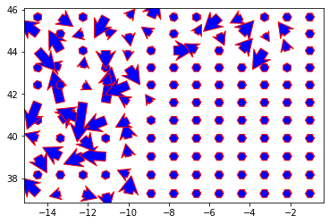

```python
z=np.zeros(10,dtype='bool')
v=np.arange(10)
z[::3]=True
print(z)
print(v)
print(v[z])

a=np.load('data/uv/uv_iberia.npz')
print(list(a))
a['mask']
M=np.zeros(a['lon'].shape,dtype='bool')
d=4
M[::d,::d]=1
opts=dict(width=0.015,scale=150,headlength=2,headwidth=2.2,headaxislength=1.6)
pl.quiver(a['lon'][M],a['lat'][M],a['u'][M],a['v'][M],width=0.03,scale=2,
          headaxislength=1.6,headwidth=2.2,headlength=2,color='b',edgecolor='r',linewidth=1)#width=0.002)
```

```python
a=np.load('data/sst/sst_iberia.npz')
print(list(a))
a['sst']
```

```
['h', 'sst_mask', 'sst', 'time', 'y', 'x']
```

```
array([[1.53875503e+01, 1.53634057e+01, 1.53548007e+01, ...,
        1.00000000e+37, 1.00000000e+37, 1.00000000e+37],
       [1.54116948e+01, 1.52820663e+01, 1.53144722e+01, ...,
        1.00000000e+37, 1.00000000e+37, 1.00000000e+37],
       [1.53913944e+01, 1.52610637e+01, 1.52916490e+01, ...,
        1.00000000e+37, 1.00000000e+37, 1.00000000e+37],
       ...,
       [1.26284310e+01, 1.25826124e+01, 1.26944335e+01, ...,
        1.00000000e+37, 1.00000000e+37, 1.00000000e+37],
       [1.26387998e+01, 1.25696076e+01, 1.26411090e+01, ...,
        1.00000000e+37, 1.00000000e+37, 1.00000000e+37],
       [1.26415188e+01, 1.26442378e+01, 1.26524258e+01, ...,
        1.00000000e+37, 1.00000000e+37, 1.00000000e+37]])
```

```python
x=np.arange(20)
y=np.zeros((5,3))
print(x)
print(y)

np.savez('mma.npz',long=x,batatas=y)
```

```
[ 0  1  2  3  4  5  6  7  8  9 10 11 12 13 14 15 16 17 18 19]
[[0. 0. 0.]
 [0. 0. 0.]
 [0. 0. 0.]
 [0. 0. 0.]
 [0. 0. 0.]]
```

```python
z=np.load('mma.npz')
list(z)
z['long']

q=dict(nome='mma',planeta='terra')
list(q)
q['planeta']
```

```
'terra'
```

```python
x=np.arange(10)
print(x,x.max())
x.max()
x=np.ma.masked_where(x>5,x)
print(x,x.max())
x**2
```

```
[0 1 2 3 4 5 6 7 8 9] 9
[0 1 2 3 4 5 -- -- -- --] 5
```

```
masked_array(data=[0, 1, 4, 9, 16, 25, --, --, --, --],
             mask=[False, False, False, False, False, False,  True,  True,
                    True,  True],
       fill_value=999999)
```